# 2018 SFEI RMP Data Challenge

## Machine Learning Analysis of Nutrients in the SF Bay

### Author: Walter Yu, P.E.

### Abstract

Nutrients present in the SF Bay are linked to higher algae blooms and toxins which result in lower dissolved oxygen (DO), negative impacts to fish habitat and lower overall water quality. This topic featured in the 2017 Pulse of the Bay$^{1}$, which included data analysis of SF Bay monitoring results; as a result, this study continues such analysis with machine learning to identify other potential insights from nutrient monitoring data.

### Introduction

This study outlines the data, methods and results used to identify trends in the SF Estuary Institute (SFEI) Regional Monitoring Program (RMP) water quality and toxicity monitoring results from the Contaminant Data Display and Download (CD3) database$^{2}$. Specifically, it seeks to answer the following questions:

1. Which data attributes most influence DO, chlorophyll-a (Chl-a), ammonium (as N) and ammonia (as NH^3) levels?
2. Does identifying these attributes lead to insights regarding possible causes for increasing nutrients?
3. What trends were identified with this study?
4. What are some next steps and recommendations based on additional analysis?

### Data Source

This study analyzes the DO, chlorophyll-a (Chl-a), ammonium (as N) and ammonia (as NH^3) from the CD3 dataset. Specifically, nutrient monitoring results were analyzed to identify potential insights. The data was retrieved from the CD3 database by filtering for basic water quality and toxicity.

### Tools and Process

The tools and process listed below were used to analyze data and provide recommendations:

1. Jupyter Notebook - Exploratory data cleaning and organization were completed using this notebook; machine learning models were run in Microsoft Azure Machine Learning (AML) Studio
2. Python Modules - The required modules are listed within the source code and need to be installed in order to run this notebook.
3. Microsoft Azure Machine Learning (ML) Studio - ML Studio was used to identify important data features, compare machine learning algorithms and publish results.

### Data Cleaning

After data cleaning, summary statistics were prepared for the dataset per table and bar chart shown below to separate results by analyte into its own dataframe for machine learning analysis.

### Exploratory Data Analysis

The Chlorophyll-A and DO datasets were extracted into separate files and modified as follows:

1. Added "cd3sampleid" to ID column for future reference or analysis.
2. Added "resultscore" as categorical variable for classification algorithms.

```python
import csv
import pandas as pd
import numpy as np
import scipy
from scipy import stats
pd.options.mode.chained_assignment = None

# Plotting packages; documentation consulted for examples:
# Reference: https://seaborn.pydata.org/examples/index.html
import seaborn as sns
import matplotlib.pyplot as plt
plt.rcParams['figure.figsize'] = (15.0, 7.5)

# Statistics packages
import statsmodels
from statsmodels.formula.api import ols

# Image import packages
from IPython.display import Image
from IPython.core.display import HTML

# Exploratory data analysis to evaluate attributes of interest:

# Load csv data
cd3_df = pd.DataFrame.from_csv('./data/cd3-water-quality-toxicity.csv', index_col=None)

# Filter for 'programcode' = 'SF Bay RMP':
rmp_df = cd3_df.loc[cd3_df['programcode'] == 'SF Bay RMP']
# Verify count after filtering data each time:
# print(rmp_df.describe())

# Drop all zero result values:
rmp_df.loc[rmp_df.result > 0]
# Verify count after filtering data each time:
# print(rmp_df.describe())

# Drop null values since they do not contribute to total:
rmp_df.dropna(subset=['result'], inplace=True)
# Verify count after filtering data each time:
# print(rmp_df.describe())

# Print reduced dataset to csv:
# rmp_df.to_csv('./data/cd3-rmp-toxicity.csv')

# Separate monitoring data by analyte type:
do_df = rmp_df.loc[rmp_df['analyte'] == 'Oxygen, Dissolved']
# do_df.to_csv('./data/cd3-rmp-do.csv')
# print('Summary Statistics - Dissolved Oxygen')
# print(do_df.describe())

cla_df = rmp_df.loc[rmp_df['analyte'] == 'Chlorophyll a']
# cla_df.to_csv('./data/cd3-rmp-cla.csv')
# print('Summary Statistics - Chlorophyll-a')
# print(cla_df.describe())

amm_n = rmp_df.loc[rmp_df['analyte'] == 'Ammonia s N']
# amm_n.to_csv('./data/cd3-rmp-amm-n.csv')
# print('Summary Statistics - Ammonia as N')
# print(amm_n.describe())

amm_nh3 = rmp_df.loc[rmp_df['analyte'] == 'Ammonia as NH3']
# amm_nh3.to_csv('./data/cd3-rmp-amm-nh3.csv')
# print('Summary Statistics - Ammonia as NH3')
# print(amm_nh3.describe())

amm_nh3_union = rmp_df.loc[rmp_df['analyte'] == 'Ammonia as NH3, Unionized']
# amm_nh3_union.to_csv('./data/cd3-rmp-amm-nh3-union.csv')
# print('Summary Statistics - Ammonia as NH3, Unionized')
# print(amm_nh3_union.describe())

# Convert to datetime for time series analysis:
rmp_df.sampledate = pd.to_datetime(rmp_df.sampledate)

# Copy year/month into separate column as numeric values
rmp_df['year'] = rmp_df['sampledate'].dt.year
rmp_df['month'] = rmp_df['sampledate'].dt.month
rmp_df['day'] = rmp_df['sampledate'].dt.day
```

```
** Summary Statistics for SF Bay RMP Monitoring Data **
                                    sum       median          mean  \
analyte
SpecificConductivity       1.738697e+07  36065.00000  28882.012458
Survival                   3.444500e+04    100.00000     94.112022
Total Suspended Solids     2.033880e+04     29.76139     61.820075
pH                         1.321232e+04      7.56000      7.489977
Salinity                   1.267791e+04     23.80000     18.809955
Temperature                1.193130e+04     19.80000     18.299540
Oxygen, Dissolved          5.473636e+03      7.65000      7.786111
StationWaterDepth          4.356800e+03      4.00000      5.174347
Chlorophyll a              3.461397e+03      2.99782     10.585312
Pheophytin a               1.633270e+03      2.01000      5.251672
Ammonium as N              4.830410e+02      0.91000      1.538347
Biomass (wt/orig indiv)    9.429750e+01      0.33000      0.329712
Sulfide, Total             4.072154e+01      0.16815      0.226231
Hydrogen Sulfide           6.966661e+00      0.02400      0.045238
Ammonia as NH3             2.000000e-02      0.00000      0.000435
Ammonia as NH3, Unionized  0.000000e+00      0.00000      0.000000

                                    std  count
analyte
SpecificConductivity       17598.720482    602
Survival                      11.027538    366
Total Suspended Solids        90.155660    329
pH                             0.578172   1764
Salinity                      11.507355    674
Temperature                    4.017738    652
Oxygen, Dissolved              1.530298    703
StationWaterDepth              3.824044    842
Chlorophyll a                 38.096510    327
Pheophytin a                  23.419716    311
Ammonium as N                  1.840748    314
Biomass (wt/orig indiv)        0.078614    286
Sulfide, Total                 0.207154    180
Hydrogen Sulfide               0.061912    154
Ammonia as NH3                 0.002949     46
Ammonia as NH3, Unionized      0.000000     36
```

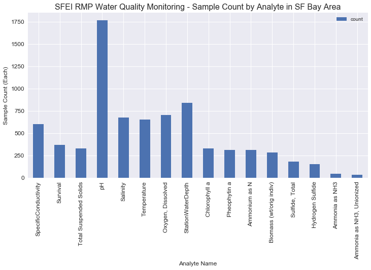

```python
# Show summary statistics for analytes data:
rmp_summary = rmp_df.groupby('analyte')['result']\
.agg([np.sum, np.median, np.mean, np.std, 'count'])\
.sort_values(by=['sum'], ascending=False)
print('** Summary Statistics for SF Bay RMP Monitoring Data **')
print(rmp_summary)

ax = rmp_summary[['count']].plot(kind='bar', title ="Sample Count (Each)", figsize=(12, 6), legend=True, fontsize=12)
plt.title('SFEI RMP Water Quality Monitoring - Sample Count by Analyte in SF Bay Area', fontsize=16)
ax.set_xlabel("Analyte Name", fontsize=12)
ax.set_ylabel("Sample Count (Each)", fontsize=12)
plt.show()
```

### Machine Learning Analysis

The datasets analyzed in Azure Machine Learning (AML) Studio as follows:

1. Load datasets as CSV files into AML
2. Create workflows for Chlorophyll-A$^{4}$ and DO$^{5}$ datasets
3. Each workflow trained dataset with various classification algorithms
4. Algorithms evaluated the "resultscore" data attribute
5. Accuracy and feature important was evaluated from each workflow

### Results

Results of each workflow were as listed below; tables accuracy and feature importance are shown in the main contest entry submittal. Fewer data attributes were included in the workflow to control the study scope which affected the results.

Chlorophyll-A Data:

1. Logistic regression algorithm performed the best; however, accuracy was ~50% which may have been due too few features being included for analysis.
2. Water body and station locations had a mild influence on result score.

Dissolved Oxygen Data:

1. Logistic regression algorithm performed the best; however, accuracy was ~50% which may have been due too few features being included for analysis.
2. Water body and station locations had a mild influence on result score.

### Next Steps

The following steps can be taken to further improve the model based on data exploration, visualization and modeling:

1. Include additional data attributes into AML workflow to improve accuracy.
2. Analyze feature important of additional attributes.
3. Specifically, consider collection date/time and location (lat/long).
4. Discuss/review results with SFEI subject matter experts.

Assumptions made in this study are based on available literature; as a result, review and discussion with SFEI subject matter experts would provide additional insights. Specifically, how to interpret the results and develop a narrative around the results.

### Conclusion

Although the results of this study were affected by control of scope, it provides a good start to machine learning analysis of nutrients in the SF Bay for additional analysis and consideration.

### Citations

$^{1}$ 2017 SFEI Pulse of the Bay, Nutrients Article (p.22): https://www.sfei.org/documents/pulse-bay-25th-anniversary-rmp  
$^{2}$ SFEI CD3 Database: https://cd3.sfei.org/  
$^{3}$ World Health Organization (WHO) Water Quality Standards: http://www.who.int/water_sanitation_health/resourcesquality/wpcchap2.pdf  
$^{4}$ AML for Chlorophyll-A: https://gallery.azure.ai/Experiment/SFEI-RMP-Classification-Evaluation-Chlorophyll-A  
$^{5}$ AML for DO: https://gallery.azure.ai/Experiment/SFEI-RMP-Classification-Evaluation-Dissolved-Oxygen

### Terms and Definitions

DO: Dissolved Oxygen  
RMP: Regional Monitoring Program  
SFEI: San Francisco Estuary Institute